# Measuring Socio-Demographics in CSS Research

Survey Research Methodology II

Author

Marga Torre

## 1 Why we need socio-demographic information

Socio-demographic information is central to social science research. Variables such as age, gender, education, income, or occupation help us understand how people differ in their behaviors, attitudes, and life chances. These variable allow researchers to compare groups, study social inequalities, and analyze how policies affect different segments of the population. They are also essential for planning and forecasting social and economic change.

In short, socio-demographics provide the basic tools to understand patterns, differences, and inequalities in society.

## 2 Demographic standards

### 2.1 Sex

*Sex* is frequently collected in two categories (namely, male and female)

- Intersexuality and transsexuality are (usually) not covered
- Observational measure (annotated by interviewer)

Recently, some surveys have included questions about sex of birth and gender identity

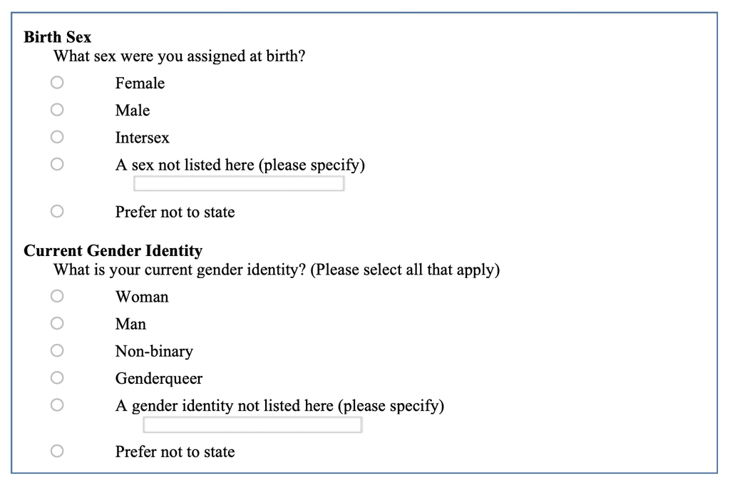

birth sex and gender identity

### 2.2 Age

The year of birth and month of birth are often collected to calculate the age of the individual at the moment of the interview. Age is calculated as follows:

$\ age=year/month(survey) - year/month(birth)$

This approach allows for adjustments to be made in response to any age-related cut-off dates for survey participation

### 2.3 Education

Educational attainment is typically measured by:

1. The highest level of general education achieved
2. Vocational education completed
3. The number of years spent enrolled in the school system

However, **education systems vary a lot between countries** and **evolve over time!** $\rightarrow$ data needs to be harmonized using robust criteria to ensure comparability across countries. ISCED is the **International Standard Classification of Education**. Developed by UNESCO in the 1970s, it is the **official framework used to facilitate international comparisons of education systems**.

| ISCED 2011 | Education level |
| --- | --- |
| **ISCED 01** | Early childhood education (under 3 years old) |
| **ISCED 02** | Pre-primary education (around ages 3–5) |
| **ISCED 1** | Primary education |
| **ISCED 2** | Lower secondary education (middle school) |
| **ISCED 3** | Upper secondary education (high school) |
| **ISCED 4** | Post-secondary non-tertiary education |
| **ISCED 5** | Short-cycle tertiary education (e.g. higher vocational) |
| **ISCED 6** | Bachelor’s degree |
| **ISCED 7** | Master’s degree |
| **ISCED 8** | Doctoral degree (PhD) |

**ISCED 2011** has been used in all EU data collections since 2014. It replaces **ISCED 1997**, with the following equivalences:

| ISCED 2011 | Equivalent in ISCED 1997 |
| --- | --- |
| ISCED 01 | – |
| ISCED 02 | ISCED 0 |
| ISCED 1 | ISCED 1 |
| ISCED 2 | ISCED 2 |
| ISCED 3 | ISCED 3 |
| ISCED 4 | ISCED 4 |
| ISCED 5 | – |
| ISCED 6 | ISCED 5 |
| ISCED 7 | – |
| ISCED 8 | ISCED 6 |

For simplicity, education levels can also be grouped into a three-category variable.

| Education level | ISCED 2011 (from 2014) | ISCED 1997 (until 2013) |
| --- | --- | --- |
| Low education | Levels 0–2 | Levels 0–2 |
| Medium education | Levels 3–4 | Levels 3–4 |
| High education | Levels 5–8 | Levels 5–6 |

In addition, the **ISCED-F** classification categorizes education programmes and qualifications by **field of study**, facilitating international comparisons of education statistics.

| Code | Broad field of education (ISCED-F 2013) |
| --- | --- |
| 00 | Generic programmes and qualifications |
| 01 | Education |
| 02 | Arts and humanities |
| 03 | Social sciences, journalism and information |
| 04 | Business, administration and law |
| 05 | Natural sciences, mathematics and statistics |
| 06 | Information and Communication Technologies (ICTs) |
| 07 | Engineering, manufacturing and construction |
| 08 | Agriculture, forestry, fisheries and veterinary |
| 09 | Health and welfare |
| 10 | Services |

### 2.4 Income

Income is a key indicator of socio-economic status and plays an important role in understanding individual behavior. When analyzing income data, several aspects should be considered:

- **Personal vs. household income**: Household income refers to the combined net earnings of all eligible individuals living in the same dwelling, regardless of their relationship.
- **Income definition**: Income can be measured as gross, net, or disposable income.
- **Time reference**: Income is usually reported on a monthly or annual basis.

A common challenge in income surveys is the **high rate of non-response**, which tends to increase as questions become more detailed. For this reason, missing income values are often imputed to ensure reliable analysis.

#### 2.4.1 Interval-Based income questions

Incorporating an interval scale into multiple-choice questions means assigning a range of values to each option, allowing respondents to choose the bracket that best reflects their situation or opinion. This method enhances data accuracy by capturing responses within defined intervals.

| Income category |
| --- |
| Less than $10,000 |
| $10,000 – $50,000 |
| $50,000 – $100,000 |
| $100,000 – $150,000 |
| I prefer not to say |

The more income bands that are proposed, the greater the measurement precision; however, this also increases the likelihood of non-response and misclassification

#### 2.4.2 Income Decile-based questions

Income decile-based questions involve categorizing respondents into ten distinct groups according to their income levels, with each decile representing an equal tenth of the population.

**Advantages**: They ensure an equal distribution of individuals across these categories

**Disadvantages**: Defining the income bands requires data from external sources, such as the Census, Labor Force Surveys, or budgetary surveys.

### 2.5 Occupational category

An individual’s **occupation** is an important factor for understanding attitudes and behavior. To compare occupations across countries, they are classified using national or international systems.

Examples of national classifications include:

- **CNO** (Spain)
- **NOC** (Canada)
- **SOC** (United States)
- **KldB** (Germany)

For international comparisons, researchers commonly use the **International Standard Classification of Occupations (ISCO)**, developed by the International Labour Organization (ILO).

ISCO groups jobs based on the **type of work and skills required**, using a hierarchical structure. To link national classifications to ISCO, **crosswalks** are used, making international comparisons possible.

#### 2.5.1 Occupational category - major groups

Major Groups (1-digit):

1. Managers
2. Professionals
3. Technicians and Associate Professionals
4. Clerical Support Workers
5. Services and Sales Workers
6. Skilled Agricultural, Forestry and Fishery Workers
7. Craft and Related Trades Workers
8. Plant and Machine Operators and Assemblers
9. Elementary Occupations
10. Armed Forces Occupations

It can be easily grouped in three categories[^1]:

| Status group | Categories |
| --- | --- |
| High-status workers | 1–2 |
| Medium-status workers | 3–5 |
| Low-status workers | 7–9 |

### 2.6 Social class

Social class is a key concept in social science because it strongly shapes **people’s life chances, attitudes, and access to resources**. It helps explain differences in income, education, health, and opportunities between social groups, and it is closely linked to **social identity, lifestyles, and political behavior**.

There is an important debate between economists and sociologists about how to measure social class:

- **Economists** usually use **income** as an indicator of social class (often called *socio-economic status*).
- **Sociologists** focus more on **occupation**, arguing that income alone does not capture changes in the social structure.

This distinction matters. For example, consider the daughter of a skilled industrial worker at Renault in Valladolid who earns a PhD in economics and becomes a post-doctoral researcher at the University of Valladolid. This example is discussed in *[Polavieja (2020)](https://doi.org/10.3989/ris.2020.78.3.20.00)*.

- **From an economic perspective**, she may appear socially immobile or even downwardly mobile, since her income at age 30 is lower than her father’s income at age 55.
- **From a sociological perspective**, this is a clear case of upward mobility, because her occupation offers better long-term opportunities and life chances.

[Here](https://people.unil.ch/danieloesch/scripts/) is an example of how to generate a social class variable using occupational data, developed by sociologist Daniel Oesch.

## 3 Useful references

- Oesch, D. (2006a) “Coming to grips with a changing class structure” *International Sociology* 21 (2): 263-288.
- Oesch, D. (2006b) “Redrawing the Class Map. Stratification and Institutions in Britain, Germany, Sweden and Switzerland”, Basingstoke: Palgrave Macmillan.

## Footnotes

[^1]: agricultural workers (category 6) are usally removed from the sample since they have very distinctive attributes and working conditions